# A model of graphic diversity in marks on paleolithic artefacts based on distance to neighboring sites

Christian Stenbro

2024-12-09

## 0. Set-up

```r
# importing packages
pacman::p_load(tidyverse,
               ggplot2,
               ggrepel,
               spatstat.geom,
               viridis,
               nngeo,
               geosphere,
               rethinking)
```

## 1. Initial data processing and visualisation of the archeological sites

Importing data:

```r
# importing sign base
sign_base <- read_csv("/Users/christianstenbro/AU/5_sem/Cultural Data Science/Geometric Signs Project/data/signBase_Version1.0.csv")
# composing a vector with all feature variable names
feature_columns <- colnames(sign_base)[25:55]

# computing the number of unique features pr. site
unique_features_pr_site <- sign_base %>%
  group_by(site_name) %>%
  summarise(unique_features = sum(colSums(across(feature_columns)) > 0))
# adding this to the sign_base data frame:
sign_base <- merge(sign_base, unique_features_pr_site, by = "site_name")
```

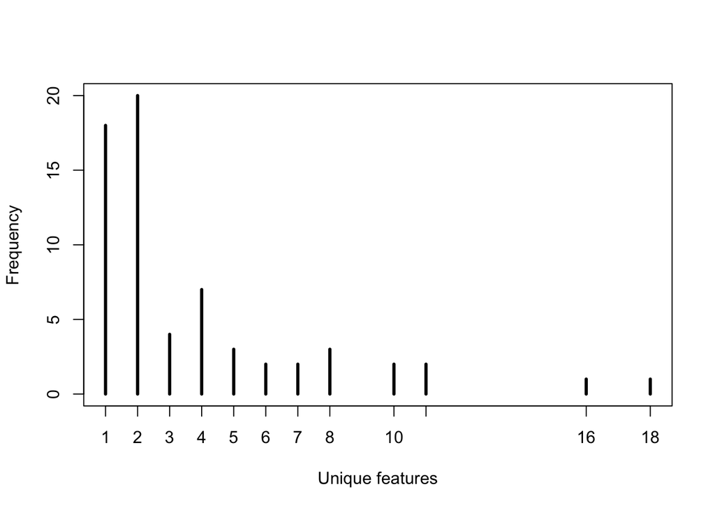

```r
# constructing subset with only a single row pr. site
sign_base_subset <- sign_base %>% group_by(site_name) %>%
  slice_sample(n=1) %>%
  ungroup

# observing the distribution of features
simplehist(sign_base_subset$unique_features,
           xlab = "Unique features")
```

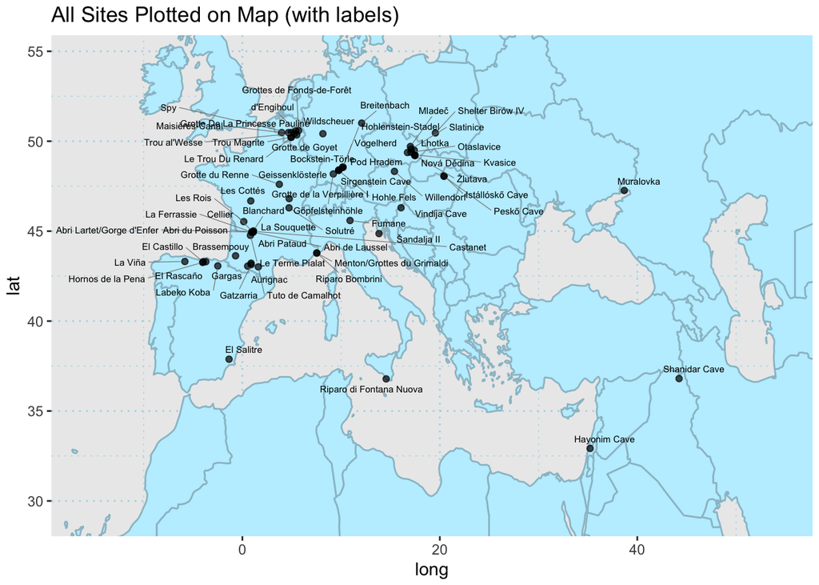

```r
# loading world coordinates
world_coordinates <- map_data("world")

# determining the bounds for zooming
padding_factor <- 0.2
long_range <- range(sign_base_subset$longitude, na.rm = TRUE)
lat_range <- range(sign_base_subset$latitude, na.rm = TRUE)

# expand the range by a fixed percentage
long_range <- c(
  long_range[1] - diff(long_range) * padding_factor,
  long_range[2] + diff(long_range) * padding_factor
)
lat_range <- c(
  lat_range[1] - diff(lat_range) * padding_factor,
  lat_range[2] + diff(lat_range) * padding_factor
)

# creating plot
sample_plot <- ggplot() +
  geom_map(
    data = world_coordinates, map = world_coordinates,
    aes(long, lat, map_id = region),
    color = "lightblue3", fill = "lightblue1"
  ) +
  geom_point(
    data = sign_base_subset,
    aes(longitude, latitude),
    size = 1.5,
    alpha = 0.7
  ) +
  geom_text_repel(
    data = sign_base_subset,
    aes(longitude, latitude, label = site_name),
    size = 2,
    max.overlaps = Inf,
    box.padding = 0.2,
    point.padding = 0.2,
    segment.color = "grey50",
    segment.size = 0.2
  ) +
  coord_cartesian(
    xlim = long_range,
    ylim = lat_range
  ) +
  theme(
    legend.position = "none",
    plot.margin = margin(4, 4, 4, 4),
    panel.grid.major = element_line(color = "lightblue", linetype = "dotted"),
    panel.grid.minor = element_line(color = "lightblue", linetype = "dotted")
  ) +
  ggtitle("All Sites Plotted on Map (with labels)")
print(sample_plot)
```

### 1.1 Computing distances between sites

The next task is to compute a new variable, encoding the geographic distance between sites. The distances will be logged to counter the extreme isolation of certain sites.

It is important to notice that this process introduces a number of assumptions which are likely not completely sound - namely, whereas the map would suggest that certain sites are isolated, this appearance is likely a result of data sparsity and not necessarily a reflection of the true isolation or connectivity of the sites.

Another assumption that would not fare well if placed under scrutiny, is that adjacent sites necessarily had contact. Another obvious problem is that the artefacts are from different time periods.

While these assumptions compromise the validity of the model, the data can still be used to demonstrate the methodological idea of using geographical distances as a proxy for inter-site connectedness, and to use this a predictor variable in a regression model used to predict graphic diversity (operationalised as the number of distinct features observed on artefacts from each site).

This model is inspired by the paper from Boyd et al., 2013, where they cite research finding a statistical relationship between the population size of different island societies in Oceania and the number of distinct marine foraging tools used by each population (Kline and Boyd, 2010). This supports theoretical models of the cultural evolution of technology, predicting that larger populations with more contact to other populations *“(…) will have more diverse and more complex toolkits than small, isolated populations”*. (Boyd et al., 2013, pp. 18).

For this project, I will operationalise the relative isolation/nearness of sites as the *mean distance to the k-nearest neighbors*. Here, it is important to consider which distance measure to base the nearest neighbor search on. Following this post: https://www.vibhuagrawal.com/blog/geospatial-nearest-neighbor-search, I will use the Harversine method. There is an implementation for this method in the ‘geosphere’ R package:

```r
# trying out some tests
geography_matrix <- select(sign_base_subset, longitude, latitude)
distHaversine(c(geography_matrix$longitude[1], geography_matrix$latitude[1]), c(geography_matrix$longitude[50], geography_matrix$latitude[50]), r=6378137)
```

```
## [1] 3703508
```

```r
sign_base_subset[1,]$site_name
```

```
## [1] "Abri Lartet/Gorge d'Enfer"
```

```r
sign_base_subset[50,]$site_name
```

```
## [1] "Shanidar Cave"
```

Now, the Harversine distance should be plotted into a nearest neighbor algorithm. As a first test, I wil consider a “brute-force” method (again following the blogpost: https://www.vibhuagrawal.com/blog/geospatial-nearest-neighbor-search). In this approach, all distances between all points are decided, and the k number of points with the smallest distances are selected as neighbors.

The method is simple to conceptualize (and implement), but can be computationally expense. However, given the size of the data set (65 individual sites), I estimate that this is very possible.

First, we need to make a matrix with distances calculated for each possible pair:

```r
# defining earth radius
earth = 6378137

# setting up a empty vector of lists to store distance computations
data_structure <- vector("list", nrow(sign_base_subset))

# looping through the archaeological sites
for (i in 1:nrow(sign_base_subset)) {

  lon_site_1 <- sign_base_subset[i,]$longitude
  lat_site_1 <- sign_base_subset[i,]$latitude

  p1 <- c(lon_site_1, lat_site_1)

  distances <- numeric(nrow(sign_base_subset))

  # for each site, the Haversine distance to all other sites is computed
    for (j in 1:nrow(sign_base_subset)) {

      lon_site_2 <- sign_base_subset[j,]$longitude
      lat_site_2 <- sign_base_subset[j,]$latitude

      p2 <- c(lon_site_2, lat_site_2)

      distances[j] <- distHaversine(p1, p2, r = earth)
   }

# the distance data for site i is then stored as one of the lists in the nested list structure
data_structure[[i]] <- distances

}
```

Testing the composition of the distance matrix:

```r
# now, we can test if the matrix has the desired information
distance_matrix <- data_structure

# retrieving the distance between site 1 and 2 in the matrix
distance_matrix[[1]][2]
```

```
## [1] 1179.476
```

```r
# computing this distance manually
distHaversine(c(geography_matrix$longitude[1], geography_matrix$latitude[1]), c(geography_matrix$longitude[2], geography_matrix$latitude[2]), r=6378137)
```

```
## [1] 1179.476
```

```r
# the two are identical, which indicates that the matrix stores the correct information
distance_matrix[[1]][2] == distHaversine(c(geography_matrix$longitude[1], geography_matrix$latitude[1]), c(geography_matrix$longitude[2], geography_matrix$latitude[2]), r=6378137)
```

```
## [1] TRUE
```

The single nearest neighbor can now be found through the following simple operations:

```r
# first, an empty list is created to store the results
nn_list <- list()

# then a for loop is made to find this value for all unique sites
for (i in 1:nrow(sign_base_subset)) {

  # creating a subset of distances for the site i
  distances_i <- distance_matrix[[i]]

  # finding the smallest non-zero distance
  nn_list[i] <- min(distances_i[distances_i > 0])
}

nn_list <- unlist(unname(nn_list))

# this can now be appended to the sign base subset
sign_base_subset$nearest_neighbor <- nn_list

# and we can assess the list of nearest neighbors (here rounded for readability)
round(sign_base_subset$nearest_neighbor, digits = 2)
```

```
##  [1]      70.80    1179.48    4871.78      70.80    9034.58    1928.22
##  [7]    2162.88  118102.70  284654.06     985.56    4410.43    6282.28
## [13]   21527.98  585287.46  243923.18   30372.68    9034.58    1510.60
## [19]   20334.05   17713.33   57035.50  116416.63   20564.96   46032.79
## [25]  929209.72    1013.71    1243.65    6282.28    2674.53    3981.51
## [31]    5609.45     985.56  145727.79  101689.91   22379.29    2682.24
## [37]  139251.49   89189.85   23434.14   49305.53      14.60   16900.53
## [43] 1250485.21    2939.35   19668.99    2674.53   25527.74      14.60
## [49]  901389.19  929209.72  186947.32    1013.71   16900.53   57035.50
## [55]   20334.05    2682.24   17713.33   60170.82  230751.15    1243.65
## [61]  175030.39  151583.10   18457.16  235966.93    2939.35
```

Notice that some values will be paired - this makes sense in the case where the nearest neighbor of site x is also the nearest neighbor of site y!

We can now plot the sites, coloring them by the nearest neighbor. First, I will log the values to decrease the range and mitigate the extreme values for the most isolated sites (relative to the rest):

```r
sign_base_subset <- sign_base_subset %>% mutate(log_nearest_neighbor = log(nearest_neighbor))
```

Then, the sites are plotted:

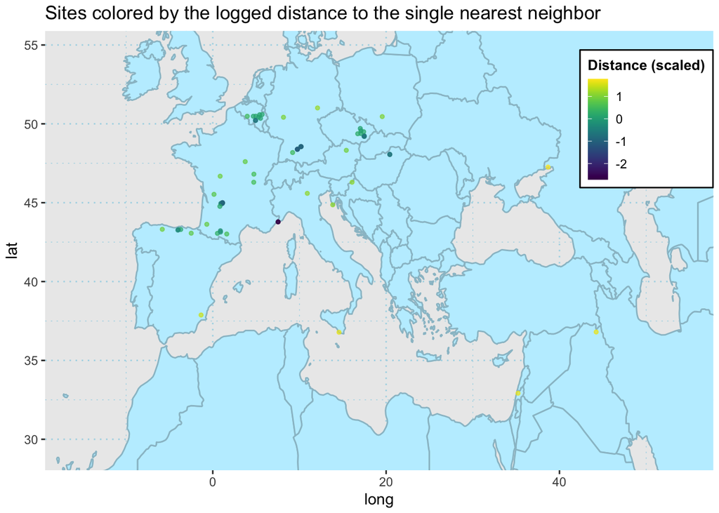

```r
sample_plot <- ggplot() +
  geom_map(
    data = world_coordinates, map = world_coordinates,
    aes(long, lat, map_id = region),
    color = "lightblue3", fill = "lightblue1"
  ) +
  geom_point(
    data = sign_base_subset,
    aes(longitude, latitude, color = scale(log_nearest_neighbor)),
    size = 1,
    alpha = 0.7
  ) +
  coord_cartesian(
    xlim = long_range,
    ylim = lat_range
  ) +
  theme(
    legend.position = c(0.90, 0.80),
    legend.background = element_rect(fill = "white", color = "black"),
    legend.key.size = unit(0.5, "cm"),
    legend.title = element_text(size = 10, face = "bold"),
    plot.margin = margin(4, 4, 4, 4),
    panel.grid.major = element_line(color = "lightblue", linetype = "dotted"),
    panel.grid.minor = element_line(color = "lightblue", linetype = "dotted")
  ) +
  viridis::scale_color_viridis() +
  labs(color = "Distance (scaled)") +
  ggtitle("Sites colored by the logged distance to the single nearest neighbor")
plot(sample_plot)
```

One interesting (and potentially problematic) consequence of using the nearest neighbor as a proxy for interconnectivity is demonstrated via the sites “Menton/Grottes du Grimaldi” [index = 41] and “Riparo Bombrini” [index = 48]. Located on opposite sites of the southernmost part of the French/Italian border, the two sites are extremely close (and appears as a single overlapping purple dot.

```r
sign_base_subset[48,]$site_name
```

```
## [1] "Riparo Bombrini"
```

```r
sign_base_subset[41,]$site_name
```

```
## [1] "Menton/Grottes du Grimaldi"
```

However, apart from the closeness of each other, the sites are relatively distant from its other nearest neighbors.

To mitigate this issue, it could be neat to incorporate the distance to not only the nearest neighbor but the *k* nearest neighbors. Or, alternatively take the mean distance from point x to all other points?

```r
# trying out taking the mean of all distances
distance_matrix_1 <- distance_matrix[[1]]
distance_matrix_2 <- distance_matrix[[2]]
distance_matrix_48 <- distance_matrix[[48]]

mean(round(log(distance_matrix_1[distance_matrix_1 > 0])))
```

```
## [1] 12.6875
```

```r
mean(round(log(distance_matrix_2[distance_matrix_2 > 0])))
```

```
## [1] 12.73438
```

```r
mean(round(log(distance_matrix_48[distance_matrix_48 > 0])))
```

```
## [1] 13.40625
```

```r
# trying out taking the mean of the three nearest neighbors
distance_matrix_1 <- sort(distance_matrix[[1]])
mean(round(log(distance_matrix_1[2:4])))
```

```
## [1] 6.333333
```

```r
distance_matrix_48 <- sort(distance_matrix[[48]])
mean(round(log(distance_matrix_48[2:4])))
```

```
## [1] 9.666667
```

Based on this test, it seems that taking the mean of the distance to the three nearest neighbors reflects the relative isolation of site 48 better than taking the mean of all distances. Hence, I will go with this approach.

```r
# setting up a loop to compute mean distance to the k nearest neighbors
k = 3

knn_list <- list()

# then a for loop is made to find this value for all unique sites
for (i in 1:nrow(sign_base_subset)) {

  # creating a subset of sorted distances for the site i
  distances_i <- sort(distance_matrix[[i]])

  # finding the k nearest neighbors (notice that the first index is always the site itself due to the sorting)
  knn_list[i] <- mean(distances_i[2:(k+1)])
}

knn_list <- unlist(unname(knn_list))

# this can now be appended to the sign base subset. Notice that the variable is logged before storage.
sign_base_subset$k_nearest_neighbor <- log(knn_list)

# and we can assess the list of nearest neighbors (here rounded for readability)
round(sign_base_subset$k_nearest_neighbor, digits = 2)
```

```
##  [1]  7.59  7.73  8.59  7.60 10.47  8.08  9.45 11.78 12.61  7.86  8.43 10.82
## [13] 10.82 13.30 12.59 10.83 10.41  9.42 10.11 10.12 11.96 12.07 10.25 10.76
## [25] 14.22  9.47  9.45 10.89 12.03  9.44  8.70  8.01 11.96 11.67 10.07 10.01
## [37] 12.06 11.43 10.18 11.06 12.35 10.30 14.10  9.48 10.09 12.04 10.44 12.35
## [49] 13.77 14.22 12.19  9.42  9.90 12.06 10.30  9.99  9.91 11.16 12.50  9.50
## [61] 12.13 12.03  9.99 12.59  9.55
```

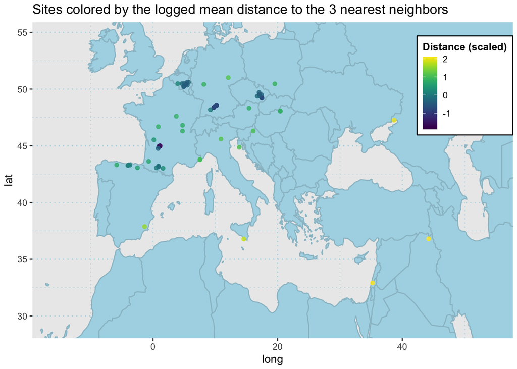

```r
# visualizing
sample_plot <- ggplot() +
  geom_map(
    data = world_coordinates, map = world_coordinates,
    aes(long, lat, map_id = region),
    color = "lightblue3", fill = "lightblue"
  ) +
  geom_point(
    data = sign_base_subset,
    aes(longitude, latitude, color = scale(k_nearest_neighbor)),
    size = 1.5,
    alpha = 0.8
  ) +
  coord_cartesian(
    xlim = long_range,
    ylim = lat_range
  ) +
  theme(
    legend.position = c(0.90, 0.80),
    legend.background = element_rect(fill = "white", color = "black"),
    legend.key.size = unit(0.5, "cm"),
    legend.title = element_text(size = 10, face = "bold"),
    plot.margin = margin(4, 4, 4, 4),
    panel.grid.major = element_line(color = "lightblue", linetype = "dotted"),  # Major grid: red and dashed
    panel.grid.minor = element_line(color = "lightblue", linetype = "dotted")
  ) +
  #scale_color_gradient2(low="blue", mid="green", high = "red") +
  labs(color = "Distance (scaled)") +
  viridis::scale_color_viridis() +
  ggtitle("Sites colored by the logged mean distance to the 3 nearest neighbors")
plot(sample_plot)
```

The visualisation based on the weighting by k nearest neighbors matches the intuitive estimation of the relative isolation of sites better than the previous attempts. Hence, this measure will be used for the statistical model in part 3.

## 3. Making a regression model of graphic feature diversity based on distance to neighboring sites

### 3.1 Specifying the model

For the analysis, I am interested in estimating the relationship between the *feature_count* of an archaeological site and its relative closeness to other sites, operationalised via the *logged distance to k_nearest_neighbor* variable computed in section 2. Since the outcome variable is a count variable, I will model it as a Poisson distribution.

I will fit the model using the Bayesian framework *ulam*. This means that I need to decide on priors for the alpha and beta estimates. In *Statistical Rethinking* (McElreath, 2020), the author fits a very similar Poisson model, using the data from Kline and Boyd, 2010. He also describes how one can go about setting priors for this kind of model.

But before deciding on priors, I will formalize the model:

Variables:
$$F_i = \text{Unique
Features}$$
$$D_i = \text{Standardised
Log Distance to K-nearest Neighbors}$$
The model can now be described as:
$$F_i \sim
\text{Poisson}(\lambda_i)$$
$$log
\lambda_i = \alpha + \beta \cdot D_i$$
$$\alpha \sim \text{some prior}$$
$$\beta \sim \text{some prior}$$
### 3.2 Selecting priors

As McElreath points out, due to the log transformation implicit in the Poisson model (we model the log of the parameter Lambda as a linear function of the predictor variable), it is important to assess how a normally distributed prior on alpha will implicate the log normal distribution of Lambda (McElreath, 2020, p. 356).

In this case, Lambda is a stand in for the number of distinct graphic features observed at an archaeological site. I would assume this to be somewhere between 1 (0 is out of the question since all the observations are based on artefacts with a graphic mark) and some upper limit for realistic diversity. This limit could be 30, which is the number of features possible in this specific data set. But realistically, an upper limit should be set higher to account for possible unobserved features still to be included in the data set, for example from excavations at other sites or deeper time periods.

Similarly, it is important to think about the expectations for the beta coefficient, which reflects the possible relationships between the relative closeness to other sites (as a proxy for interconnectivity) and the observed graphic diversity. Based on the theory informing the model (summarized in Boyd et al., 2013) I would expect a *moderately negative relationship* between the variables, as contact between groups is hypothesized to increase the cultural evolution of technological artefacts (a set which graphic marks are here assumed to belong to). Concretely, when distance is taken as a proxy for interconnectivity between groups, increases in log distance would be expected to decrease the total feature count.

Following McElreath’s example, I will put relatively restrictive priors on both alpha and beta, and then plot the distributions and relationships in the outcome (log) space. This code is reproduced more or less exactly from McElreath’s analysis on pp. 356-358 (with changed parameters):

```r
# we can compute a mean to base the alpha prior on as the exp( mu + sigma^2 / 2 )
# using 1 as mu and 0.5 as sigma would create a mean in the log normal space of the outcome variable of:
exp(1 + 0.5^2 / 2)
```

```
## [1] 3.080217
```

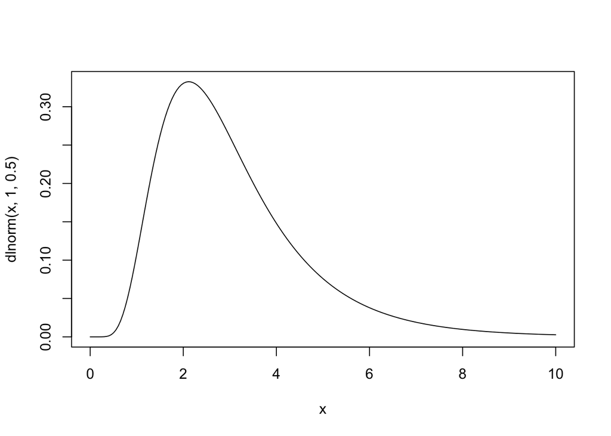

```r
# plotting this prior for alpha in log normal space
curve(dlnorm( x , 1 , 0.5 ) , from=0 , to=10 , n=200)
```

Here, x represents the mean graphic features of a given site. This is an OK prior, if perhaps a bit too restrictive (not a lot of density for higher feature). Let us try with a mu of 1.5 instead:

```r
cat("Mean graphic features:", exp(1.5 + 0.5^2 / 2))
```

```
## Mean graphic features: 5.078419
```

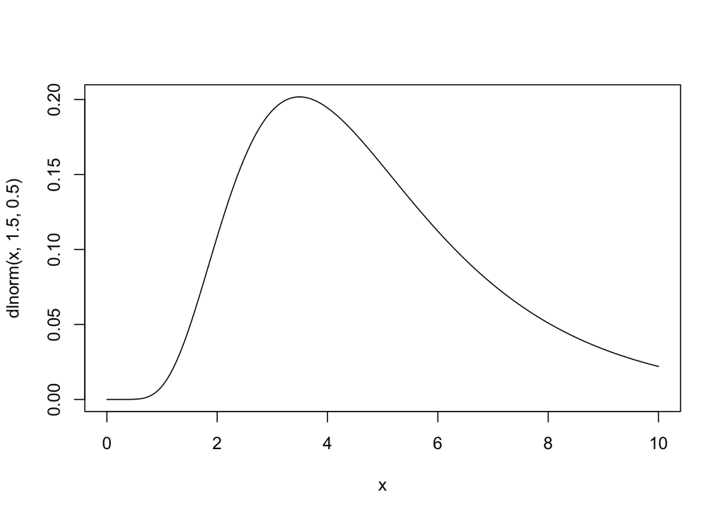

```r
curve(dlnorm( x , 1.5 , 0.5 ) , from=0 , to=10 , n=200)
```

This looks better - the distribution is a bit wider and has more density for possible higher feature counts.

And for the beta prior:

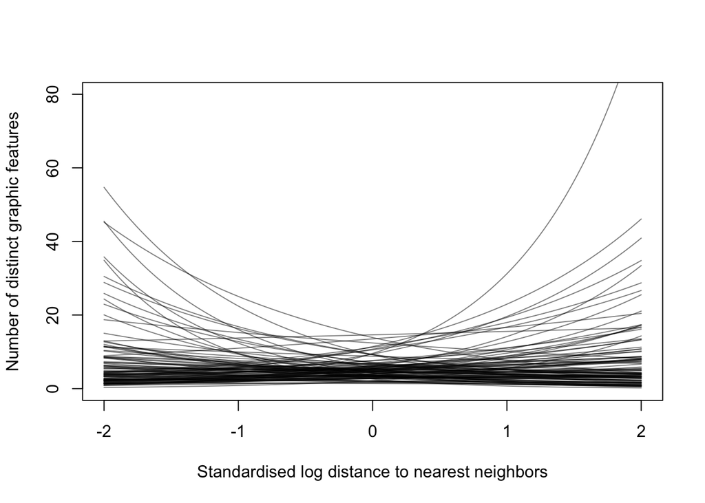

```r
N <- 100
a <- rnorm( N , 1.5 , 0.5 )
b <- rnorm( N , 0 , 0.5 )
plot( NULL , xlim=c(-2,2) , ylim=c(0,80),
      xlab = "Standardised log distance to nearest neighbors",
      ylab = "Number of distinct graphic features")
for ( i in 1:N ) curve( exp( a[i] + b[i]*x ) , add=TRUE , col=grau() )
```

This looks like a reasonable prior, as most of the relationships are within a moderate range.

### 3.3 Fitting model

I will now go ahead and fit the model. Before fitting, I will standardize the logged distance to the k-nearest neighbors.

```r
# selecting and transforming variables
dat <- list(
  F = sign_base_subset$unique_features ,
  D = scale(sign_base_subset$k_nearest_neighbor) # this variable has already been logged earlier
  )

m1.1 <- ulam(
  alist(
    F ~ dpois( lambda ),
    log(lambda) <- a + b*D,
    a ~ dnorm(1.5, 0.5),
    b ~ dnorm(0, 0.5)
  ), data=dat , chains=4 , log_lik=TRUE )
```

```
## ld: warning: duplicate -rpath '/Users/christianstenbro/.cmdstan/cmdstan-2.33.1/stan/lib/stan_math/lib/tbb' ignored
```

[output not shown]

We can now look at the summary of the posterior distributions:

```r
precis(m1.1)
```

```
##         mean         sd       5.5%      94.5%     rhat ess_bulk
## a  1.2571362 0.06710287  1.1497096  1.3635999 1.005032 1128.475
## b -0.3006811 0.06672376 -0.4068408 -0.1934472 1.004512 1339.530
```

```r
# saving the summary
model_summary <- precis(m1.1)
setwd("/Users/christianstenbro/AU/5_sem/Cultural Data Science/cult_data/assignment_3_project/model_summary")
write_csv(model_summary, "model_1_1_summary.csv")
```

And then we can plot the posterior distribution for the beta coefficient:

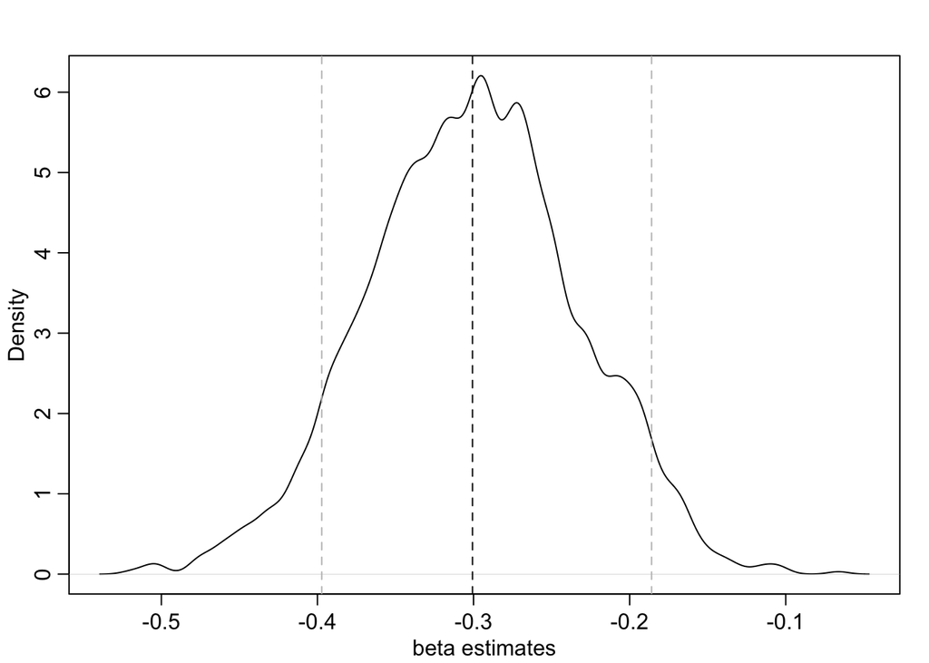

```r
post <- extract.samples( m1.1 )
density_interval <- HPDI(post$b, prob = 0.89)

dens(post$b, xlab = "beta estimates") # plotting the posterior distribution
abline(v = mean(post$b), lty = 2) # plotting the mean
abline(v = c(density_interval[[1]], density_interval[[2]]), lty = 2, col = "grey") # plotting the highest posterior density intervals
```

It is easier to interpret in the scale of the data if we take the exponential of the coefficients:

```r
# the intercept is the baseline graphic diversity when log distance = 0
exp(coef(m1.1)[[1]])
```

```
## [1] 3.51534
```

```r
# we can now build an intuition for how the model predicts changes in unique features as the log distance varies (here without accounting for error)
d <- c(seq(-2,2, 0.5))
predicted_features <- exp(coef(m1.1)[[1]]+(d*coef(m1.1)[[2]]))
print(round(predicted_features, digits = 3))
```

```
## [1] 6.414 5.519 4.748 4.086 3.515 3.025 2.602 2.239 1.927
```

While the coefficients are hard to interpret within the model, the above computation returns them to the scale of the data. We can see that the model predicts decreasing feature counts as the log distance to the three nearest sites increases.

To make the posterior distribution easier to interpret in terms of the relationship it would predict between the relative nearness of archaeological sites and the number of graphic features:

Plotting regression lines informed by the posterior distribution:

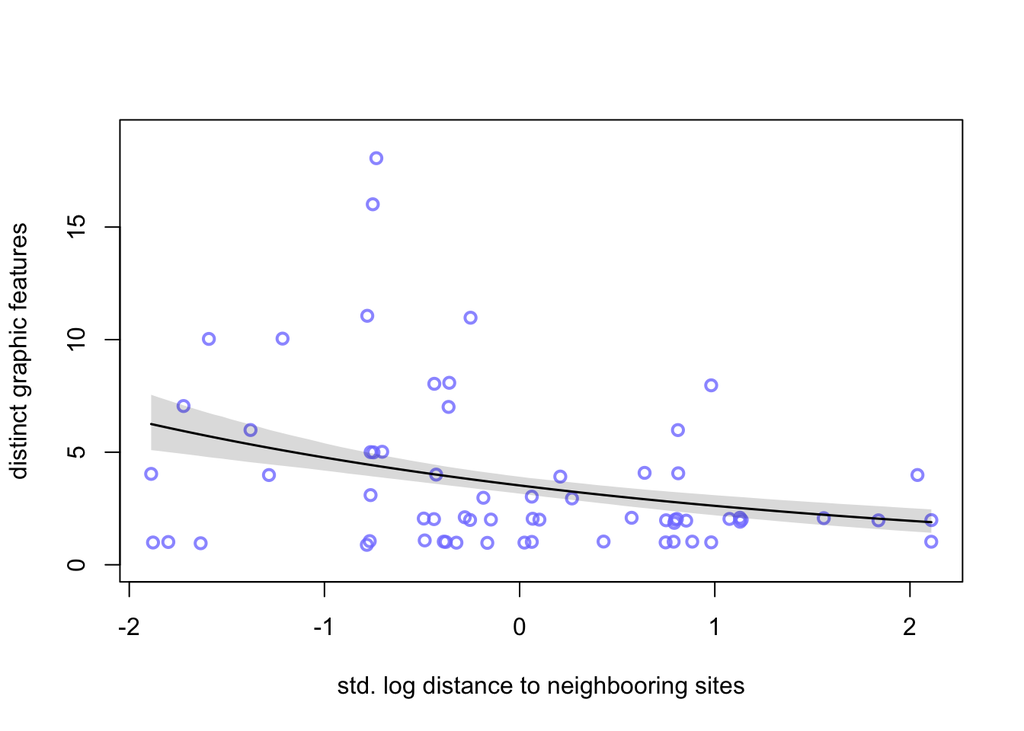

```r
# creating jitter
jitt = rnorm(length(dat$F), mean = 0, sd = 0.05)

plot( x = dat$D , y = dat$F + jitt, xlab="std. log distance to neighbooring sites" , ylab="distinct graphic features" ,
    col=col.alpha(rangi2, 0.8) , lwd=2 ,
    ylim=c(0,max(dat$F+1)) )
# setting up a grid of hypothetical log distance values to base the predictions on
resolution <- 100
D_seq <- seq( from=min(dat$D) , to=max(dat$D) , length.out=resolution )

# computing predictions for the grid values
lambda <- link( m1.1 , data=data.frame( D=D_seq ) )
lmu <- apply( lambda , 2 , mean )
lci <- apply( lambda , 2 , PI )
lines( D_seq , lmu , lty=1 , lwd=1.5 )
shade( lci , D_seq , xpd=TRUE )
```

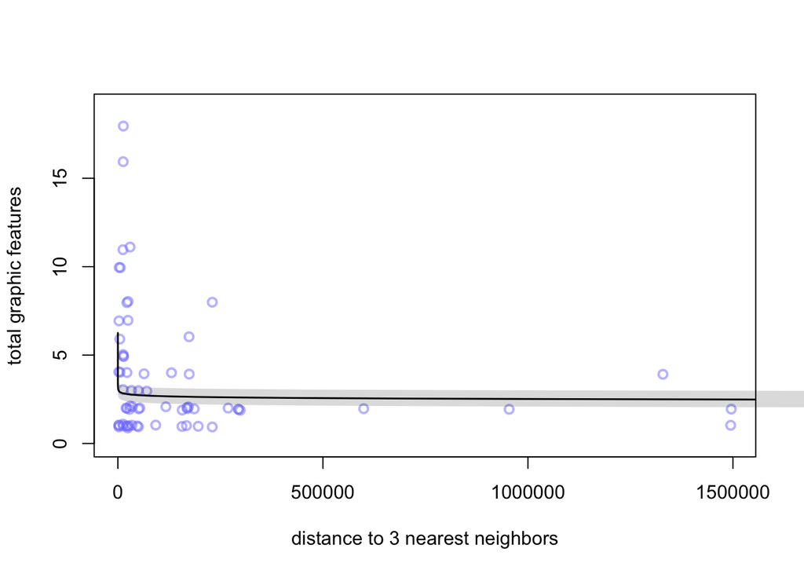

```r
# creating jitter
jitt = rnorm(length(dat$F), mean = 0, sd = 0.05)

plot( x = exp(sign_base_subset$k_nearest_neighbor), y = dat$F + jitt, xlab = "distance to 3 nearest neighbors", ylab = "total graphic features", col=col.alpha(rangi2, 0.5) , lwd=2, ylim=c(0,max(dat$F+1)))

# setting up a grid of hypothetical log distance values to base the predictions on
resolution <- 100
D_seq <- seq( from=min(dat$D) , to=max(dat$D) , length.out=resolution )
distance_seq <- exp( D_seq*mean(sign_base_subset$k_nearest_neighbor) + sd(sign_base_subset$k_nearest_neighbor))

# computing predictions for the grid values
lambda <- link( m1.1 , data=data.frame( D=D_seq ) )
lmu <- apply( lambda , 2 , mean )
lci <- apply( lambda , 2 , PI )
lines( distance_seq , lmu , lty=1 , lwd=1.5 )
shade( lci , distance_seq , xpd=TRUE )
```

There are many other issues with the current model as well; for example, the sites contains artifacts from different times, and were likely inhabited at different time depths. Using geographical distance as a single variable proxy for inter-site contact is problematic as it ignores the crucial temporal dimension, that necessarily restricts the contact possibilities.

As such, the most valuable information gained from the analysis relates to the kind of data set that would be needed to try to answer a question, such as the one posed in the beginning of this project. Specifically, such a data-set would benefit from expert validation to create a better operationalization of inter-site contact and include estimates on the time period of site activity for all sites.

In the current data set, the latter is already available for:

```r
dated_data <- sign_base %>% filter(date_bp_max_min != "NA")
cat(nrow(sign_base) - (nrow(sign_base) - nrow(dated_data)), "out of", nrow(sign_base), "sites")
```

```
## 497 out of 531 sites
```

A new modelling approach using the same data could thus be to focus on the time depth or the duration of site activity as possible predictors of graphic diversity.

## References

Boyd, R., Richerson, P. J., & Henrich, J. (2013). The Cultural Evolution of Technology: Facts and Theories. In P. J. Richerson & M. H. Christiansen (Eds.), Cultural Evolution (pp. 119–142). The MIT Press. https://doi.org/10.7551/mitpress/9894.003.0011

Kline, M. A., & Boyd, R. (2010). Population size predicts technological complexity in Oceania. Proceedings of the Royal Society B: Biological Sciences, 277(1693), 2559–2564. https://doi.org/10.1098/rspb.2010.0452

McElreath, R. (2020). Statistical Rethinking: A Bayesian Course with Examples in R and Stan (Second edition). CRC Press. https://doi.org/10.1201/9780429029608

Blogpost from ‘Vibhu’s blog’: https://www.vibhuagrawal.com/blog/geospatial-nearest-neighbor-search